# 14_Collinearity

```python
import pandas as pd
import numpy as np
import seaborn as sns
import statsmodels.api as sm
import matplotlib.pyplot as plt
%matplotlib inline
```

Generating data set with coefficients 2,2,and 0.3 & y is a function of x1 & x2

```python
# Draw random samples from a normal (Gaussian) distribution
np.random.seed(1)
x1 = np.random.normal(size=100)
x2 = 0.5*x1 + np.random.randn(100)/10
y = 2+2*x1+0.3*x2+np.random.randn(100)
```

Form of the linear model is

1. Y = beta0 + beta1 *x1 + beta2* x2 + epsilon
2. Y = 2 + 2 *x1 +0.3* x2 + epsilon

```python
corr_x1_x2 = np.corrcoef(x1,x2)[0][1]

print('Correlation between x1 & x2:', str(corr_x1_x2*100),'%')
```

```
Correlation between x1 & x2: 97.94751172441892 %
```

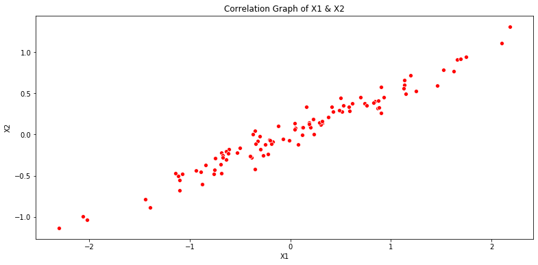

```python
fig = plt.figure(figsize=(13,6))
ax = sns.scatterplot(x1,x2,color = 'r')
ax.set_xlabel('X1')
ax.set_ylabel('X2')
ax.set_title('Correlation Graph of X1 & X2')
```

It's evident from the plot that X1 & x2 are collinear i.e. posses linear relationship as the graph follows a straight line

```python
X = np.stack((x1,x2),axis=-1)

linr_reg = sm.OLS(y,sm.add_constant(X)).fit()
linr_reg.summary()
```

OLS Regression Results

| Dep. Variable: | y | R-squared: | 0.786 |
| --- | --- | --- | --- |
| Model: | OLS | Adj. R-squared: | 0.781 |
| Method: | Least Squares | F-statistic: | 177.8 |
| Date: | Thu, 28 May 2020 | Prob (F-statistic): | 3.58e-33 |
| Time: | 10:26:29 | Log-Likelihood: | -140.24 |
| No. Observations: | 100 | AIC: | 286.5 |
| Df Residuals: | 97 | BIC: | 294.3 |
| Df Model: | 2 |  |  |
| Covariance Type: | nonrobust |  |  |

|  | coef | std err | t | P>\|t\| | [0.025 | 0.975] |
| --- | --- | --- | --- | --- | --- | --- |
| const | 1.9802 | 0.101 | 19.539 | 0.000 | 1.779 | 2.181 |
| x1 | 0.8462 | 0.560 | 1.512 | 0.134 | -0.265 | 1.957 |
| x2 | 2.4837 | 1.076 | 2.308 | 0.023 | 0.348 | 4.619 |

| Omnibus: | 0.256 | Durbin-Watson: | 2.195 |
| --- | --- | --- | --- |
| Prob(Omnibus): | 0.880 | Jarque-Bera (JB): | 0.076 |
| Skew: | -0.063 | Prob(JB): | 0.963 |
| Kurtosis: | 3.048 | Cond. No. | 12.5 |

Warnings:  
[1] Standard Errors assume that the covariance matrix of the errors is correctly specified.

true Beta0 = 2 | true Beta1 = 2 | true beta2 = 0.3

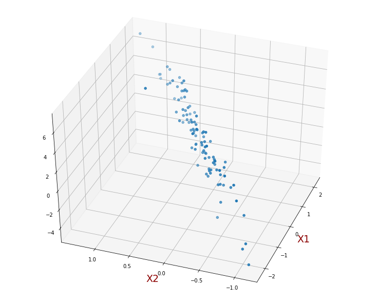

```python
dic = {'family': 'sans serif','color':  'darkred','weight': 'normal','size': 19}
from mpl_toolkits.mplot3d import Axes3D
df = pd.DataFrame({'x1':x1,'x2':x2,'y':y})
fig = plt.figure(figsize=(10,8))
ax = fig.add_subplot(Axes3D(fig))
ax.scatter(df['x1'],df['x2'],df['y'])
ax.view_init(40, 200)

plt.xlabel('X1',fontdict=dic)
plt.ylabel('X2',fontdict=dic)
```

**Fitting a linear model, with only x1 as predictor**

```python
linr_reg_x1 = sm.OLS(df.y,sm.add_constant(x1)).fit()
linr_reg_x1.summary()
```

OLS Regression Results

| Dep. Variable: | y | R-squared: | 0.774 |
| --- | --- | --- | --- |
| Model: | OLS | Adj. R-squared: | 0.772 |
| Method: | Least Squares | F-statistic: | 335.5 |
| Date: | Thu, 28 May 2020 | Prob (F-statistic): | 2.07e-33 |
| Time: | 10:26:32 | Log-Likelihood: | -142.92 |
| No. Observations: | 100 | AIC: | 289.8 |
| Df Residuals: | 98 | BIC: | 295.0 |
| Df Model: | 1 |  |  |
| Covariance Type: | nonrobust |  |  |

|  | coef | std err | t | P>\|t\| | [0.025 | 0.975] |
| --- | --- | --- | --- | --- | --- | --- |
| const | 2.0167 | 0.102 | 19.715 | 0.000 | 1.814 | 2.220 |
| x1 | 2.1118 | 0.115 | 18.317 | 0.000 | 1.883 | 2.341 |

| Omnibus: | 0.406 | Durbin-Watson: | 2.185 |
| --- | --- | --- | --- |
| Prob(Omnibus): | 0.816 | Jarque-Bera (JB): | 0.550 |
| Skew: | 0.127 | Prob(JB): | 0.759 |
| Kurtosis: | 2.739 | Cond. No. | 1.15 |

Warnings:  
[1] Standard Errors assume that the covariance matrix of the errors is correctly specified.

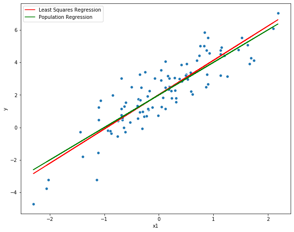

```python
# defining figure size
fig = plt.figure(figsize=(10,8))

# plotting scatter plot of x1, & y
ax = sns.scatterplot(df['x1'],df['y'],data=df)

# label axis
plt.xlabel('x1')
plt.ylabel('y')

# plotting regression & population regression line
ax.plot(df['x1'],linr_reg_x1.fittedvalues,color='r')
ax.plot(df['x1'],2+(2*df['x1']),color = 'g')
ax.legend(['Least Squares Regression', 'Population Regression'])
```

**Fitting a linear model, with only x2 as predictor**

```python
linr_reg_x2 = sm.OLS(y,sm.add_constant(x2)).fit()
linr_reg_x2.summary()
```

OLS Regression Results

| Dep. Variable: | y | R-squared: | 0.781 |
| --- | --- | --- | --- |
| Model: | OLS | Adj. R-squared: | 0.778 |
| Method: | Least Squares | F-statistic: | 348.8 |
| Date: | Thu, 28 May 2020 | Prob (F-statistic): | 4.71e-34 |
| Time: | 10:26:35 | Log-Likelihood: | -141.41 |
| No. Observations: | 100 | AIC: | 286.8 |
| Df Residuals: | 98 | BIC: | 292.0 |
| Df Model: | 1 |  |  |
| Covariance Type: | nonrobust |  |  |

|  | coef | std err | t | P>\|t\| | [0.025 | 0.975] |
| --- | --- | --- | --- | --- | --- | --- |
| const | 1.9589 | 0.101 | 19.392 | 0.000 | 1.758 | 2.159 |
| x1 | 4.0770 | 0.218 | 18.676 | 0.000 | 3.644 | 4.510 |

| Omnibus: | 1.430 | Durbin-Watson: | 2.186 |
| --- | --- | --- | --- |
| Prob(Omnibus): | 0.489 | Jarque-Bera (JB): | 0.953 |
| Skew: | -0.210 | Prob(JB): | 0.621 |
| Kurtosis: | 3.227 | Cond. No. | 2.18 |

Warnings:  
[1] Standard Errors assume that the covariance matrix of the errors is correctly specified.

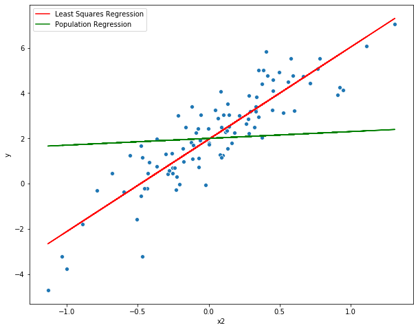

```python
fig = plt.figure(figsize=(10,8))
ax = sns.scatterplot(df['x2'],df['y'],data=df)
plt.xlabel('x2')
plt.ylabel('y')
ax.plot(df['x2'],linr_reg_x2.fittedvalues,color='r')
ax.plot(df['x2'],2+(0.3*df['x2']),color = 'g')
ax.legend(['Least Squares Regression', 'Population Regression'])
```

The contradiction of null hypothesis of x1 accepted when model is fit with both x1 & x2 and rejected when model is fit with x1 only can be explained by the collinearity of x1 and x2 which causes

1) an increased standard error for x1 & x2

2) 1 above results in p-values increase and causes us to incorrectly accept the null hypothesis when our model uses both features (x1,x2).

```python
x1 = np.append(x1,.1)
x2 = np.append(x2,0.8)
y = np.append(y,6)
```

```python
X = np.stack((x1,x2),axis=-1)
```

**The following model is fit by adding an additional observation x1 = .1 | x2 = 0.8 | y = 6**

```python
linr_reg_1 = sm.OLS(y,sm.add_constant(X)).fit()
```

```python
linr_reg_1.summary()
```

OLS Regression Results

| Dep. Variable: | y | R-squared: | 0.787 |
| --- | --- | --- | --- |
| Model: | OLS | Adj. R-squared: | 0.783 |
| Method: | Least Squares | F-statistic: | 181.6 |
| Date: | Thu, 28 May 2020 | Prob (F-statistic): | 1.10e-33 |
| Time: | 10:26:41 | Log-Likelihood: | -142.34 |
| No. Observations: | 101 | AIC: | 290.7 |
| Df Residuals: | 98 | BIC: | 298.5 |
| Df Model: | 2 |  |  |
| Covariance Type: | nonrobust |  |  |

|  | coef | std err | t | P>\|t\| | [0.025 | 0.975] |
| --- | --- | --- | --- | --- | --- | --- |
| const | 1.9772 | 0.102 | 19.382 | 0.000 | 1.775 | 2.180 |
| x1 | 0.3296 | 0.449 | 0.735 | 0.464 | -0.561 | 1.220 |
| x2 | 3.4988 | 0.851 | 4.111 | 0.000 | 1.810 | 5.188 |

| Omnibus: | 0.782 | Durbin-Watson: | 2.175 |
| --- | --- | --- | --- |
| Prob(Omnibus): | 0.676 | Jarque-Bera (JB): | 0.478 |
| Skew: | -0.159 | Prob(JB): | 0.788 |
| Kurtosis: | 3.108 | Cond. No. | 9.91 |

Warnings:  
[1] Standard Errors assume that the covariance matrix of the errors is correctly specified.

**Here's what changed compared to model fit with x1 & x2 without this additional added observation**

1. R-square value increased by .1 i.e. from 78.6% to 78.7%
2. x1 value decreased from 0.8462 to 0.32, x1 become less statistically significant as p-value further increased from 0.134 to 0.464
3. x2 value increased from 2.4837 to 3.4988, x2 become more statistically significant as p-value further decreased to 0.00 from 0.023

```python
linr_reg_1_x1 = sm.OLS(y,sm.add_constant(x1)).fit()
linr_reg_1_x1.summary()
```

OLS Regression Results

| Dep. Variable: | y | R-squared: | 0.751 |
| --- | --- | --- | --- |
| Model: | OLS | Adj. R-squared: | 0.748 |
| Method: | Least Squares | F-statistic: | 298.4 |
| Date: | Thu, 28 May 2020 | Prob (F-statistic): | 1.23e-31 |
| Time: | 10:26:42 | Log-Likelihood: | -150.37 |
| No. Observations: | 101 | AIC: | 304.7 |
| Df Residuals: | 99 | BIC: | 310.0 |
| Df Model: | 1 |  |  |
| Covariance Type: | nonrobust |  |  |

|  | coef | std err | t | P>\|t\| | [0.025 | 0.975] |
| --- | --- | --- | --- | --- | --- | --- |
| const | 2.0540 | 0.108 | 19.012 | 0.000 | 1.840 | 2.268 |
| x1 | 2.1137 | 0.122 | 17.273 | 0.000 | 1.871 | 2.356 |

| Omnibus: | 5.191 | Durbin-Watson: | 2.006 |
| --- | --- | --- | --- |
| Prob(Omnibus): | 0.075 | Jarque-Bera (JB): | 4.577 |
| Skew: | 0.432 | Prob(JB): | 0.101 |
| Kurtosis: | 3.584 | Cond. No. | 1.15 |

Warnings:  
[1] Standard Errors assume that the covariance matrix of the errors is correctly specified.

```python
linr_reg_1_x2 = sm.OLS(y,sm.add_constant(x2)).fit()
linr_reg_1_x2.summary()
```

OLS Regression Results

| Dep. Variable: | y | R-squared: | 0.786 |
| --- | --- | --- | --- |
| Model: | OLS | Adj. R-squared: | 0.784 |
| Method: | Least Squares | F-statistic: | 364.3 |
| Date: | Thu, 28 May 2020 | Prob (F-statistic): | 5.98e-35 |
| Time: | 10:33:24 | Log-Likelihood: | -142.62 |
| No. Observations: | 101 | AIC: | 289.2 |
| Df Residuals: | 99 | BIC: | 294.5 |
| Df Model: | 1 |  |  |
| Covariance Type: | nonrobust |  |  |

|  | coef | std err | t | P>\|t\| | [0.025 | 0.975] |
| --- | --- | --- | --- | --- | --- | --- |
| const | 1.9652 | 0.100 | 19.561 | 0.000 | 1.766 | 2.165 |
| x1 | 4.1038 | 0.215 | 19.087 | 0.000 | 3.677 | 4.530 |

| Omnibus: | 1.472 | Durbin-Watson: | 2.181 |
| --- | --- | --- | --- |
| Prob(Omnibus): | 0.479 | Jarque-Bera (JB): | 1.005 |
| Skew: | -0.220 | Prob(JB): | 0.605 |
| Kurtosis: | 3.212 | Cond. No. | 2.16 |

Warnings:  
[1] Standard Errors assume that the covariance matrix of the errors is correctly specified.

**Model A**

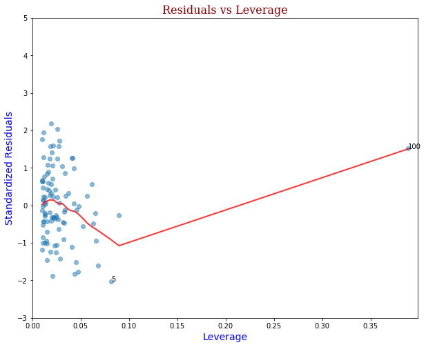

```python
# model residual
model_resudial_A = linr_reg_1.resid

# model normalized residuals
model_norm_residual_A = linr_reg_1.get_influence().resid_studentized_internal

#leverage
model_leverage_A = linr_reg_1.get_influence().hat_matrix_diag

# cooks distance
model_cooks = linr_reg_1.get_influence().cooks_distance[0]


heading_font = {'family': 'serif','color':  'darkred','weight': 'normal','size': 16}
axis_font = {'family': 'sans serif','color':  'blue','weight': 'normal','size': 14}

Figure_1 = plt.figure(figsize=(10,8));
plt.scatter(model_leverage_A, model_norm_residual_A, alpha=0.5);
sns.regplot(model_leverage_A, model_norm_residual_A,
              scatter=False,
              ci=False,
              lowess=True,
              line_kws={'color': 'red', 'lw': 2, 'alpha': 0.8});
Figure_1.axes[0].set_xlim(0, max(model_leverage_A)+0.01)
Figure_1.axes[0].set_ylim(-3, 5)
Figure_1.axes[0].set_title('Residuals vs Leverage',fontdict=heading_font)
Figure_1.axes[0].set_xlabel('Leverage',fontdict=axis_font)
Figure_1.axes[0].set_ylabel('Standardized Residuals',fontdict=axis_font);

leverage_top_3 = np.flip(np.argsort(model_cooks), 0)[:3]
for i in leverage_top_3:
    Figure_1.axes[0].annotate(i,xy=(model_leverage_A[i],
                                     model_norm_residual_A[i]));
```

**Model B**

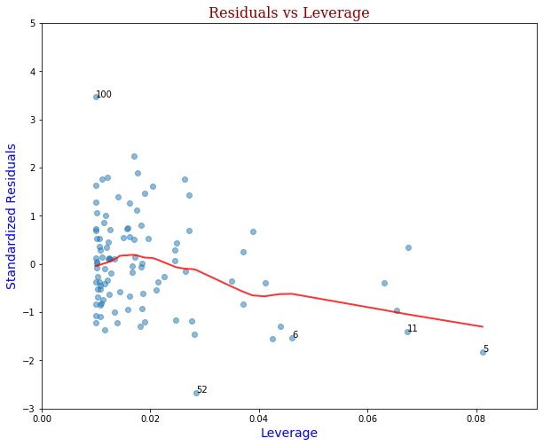

```python
# model residual
model_resudial_B = linr_reg_1_x1.resid

# model normalized residuals
model_norm_residual_B = linr_reg_1_x1.get_influence().resid_studentized_internal

#leverage
model_leverage_B = linr_reg_1_x1.get_influence().hat_matrix_diag

# cooks distance
model_cooks = linr_reg_1_x1.get_influence().cooks_distance[0]


heading_font = {'family': 'serif','color':  'darkred','weight': 'normal','size': 16}
axis_font = {'family': 'sans serif','color':  'blue','weight': 'normal','size': 14}

Figure_1 = plt.figure(figsize=(10,8));
plt.scatter(model_leverage_B, model_norm_residual_B, alpha=0.5);
sns.regplot(model_leverage_B, model_norm_residual_B,
              scatter=False,
              ci=False,
              lowess=True,
              line_kws={'color': 'red', 'lw': 2, 'alpha': 0.8});
Figure_1.axes[0].set_xlim(0, max(model_leverage_B)+0.01)
Figure_1.axes[0].set_ylim(-3, 5)
Figure_1.axes[0].set_title('Residuals vs Leverage',fontdict=heading_font)
Figure_1.axes[0].set_xlabel('Leverage',fontdict=axis_font)
Figure_1.axes[0].set_ylabel('Standardized Residuals',fontdict=axis_font);

leverage_top_5 = np.flip(np.argsort(model_cooks), 0)[:5]
for i in leverage_top_5:
    Figure_1.axes[0].annotate(i,xy=(model_leverage_B[i],
                                     model_norm_residual_B[i]));
```

**Model C**

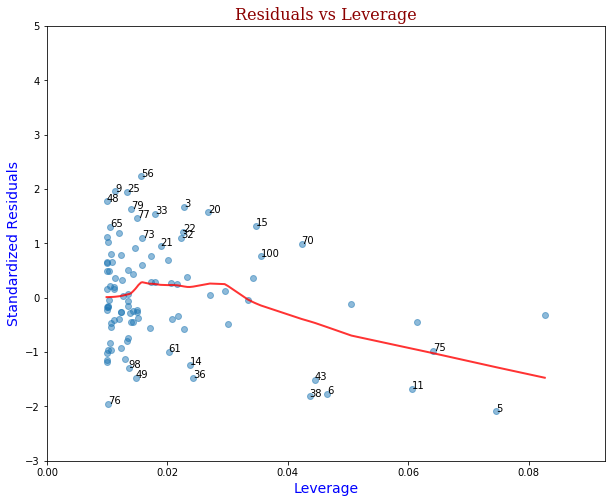

```python
# model residual
model_resudial_C = linr_reg_1_x2.resid

# model normalized residuals
model_norm_residual_C = linr_reg_1_x2.get_influence().resid_studentized_internal

#leverage
model_leverage_C = linr_reg_1_x2.get_influence().hat_matrix_diag

# cooks distance
model_cooks = linr_reg_1_x2.get_influence().cooks_distance[0]


heading_font = {'family': 'serif','color':  'darkred','weight': 'normal','size': 16}
axis_font = {'family': 'sans serif','color':  'blue','weight': 'normal','size': 14}

Figure_1 = plt.figure(figsize=(10,8));
plt.scatter(model_leverage_C, model_norm_residual_C, alpha=0.5);
sns.regplot(model_leverage_C, model_norm_residual_C,
              scatter=False,
              ci=False,
              lowess=True,
              line_kws={'color': 'red', 'lw': 2, 'alpha': 0.8});
Figure_1.axes[0].set_xlim(0, max(model_leverage_C)+0.01)
Figure_1.axes[0].set_ylim(-3, 5)
Figure_1.axes[0].set_title('Residuals vs Leverage',fontdict=heading_font)
Figure_1.axes[0].set_xlabel('Leverage',fontdict=axis_font)
Figure_1.axes[0].set_ylabel('Standardized Residuals',fontdict=axis_font);

leverage_top_30 = np.flip(np.argsort(model_cooks), 0)[:30]
for i in leverage_top_30:
    Figure_1.axes[0].annotate(i,xy=(model_leverage_C[i],
                                     model_norm_residual_C[i]));
```

1. Model_A: Additional observation (point annotated 100 in the plot) in model A is a leverage point but not an outlier
2. Model_B: Additional observation in model B (point annotated 100 in the plot) is an outlier and not a leverge point
3. Model_C: Additional observation in model C (point annotated 100 in the plot) neither an outlier nor a leverge point